# 市场观察

2017/07/11

## A、指数估值

### (a1)动态市盈率、市净率

核心指数成分股近18个月的动态市盈率及动态市净率中位数走势如下图所示：

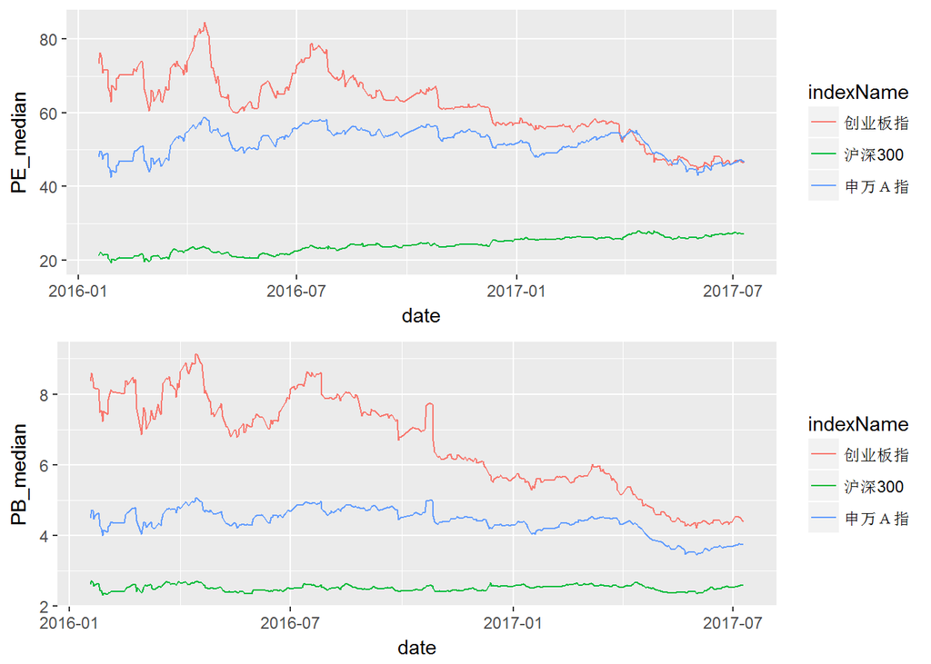

### (a2)动态市盈率、市净率百分位

核心指数近18个月的动态市盈率百分位及动态市净率百分位走势如下图所示：

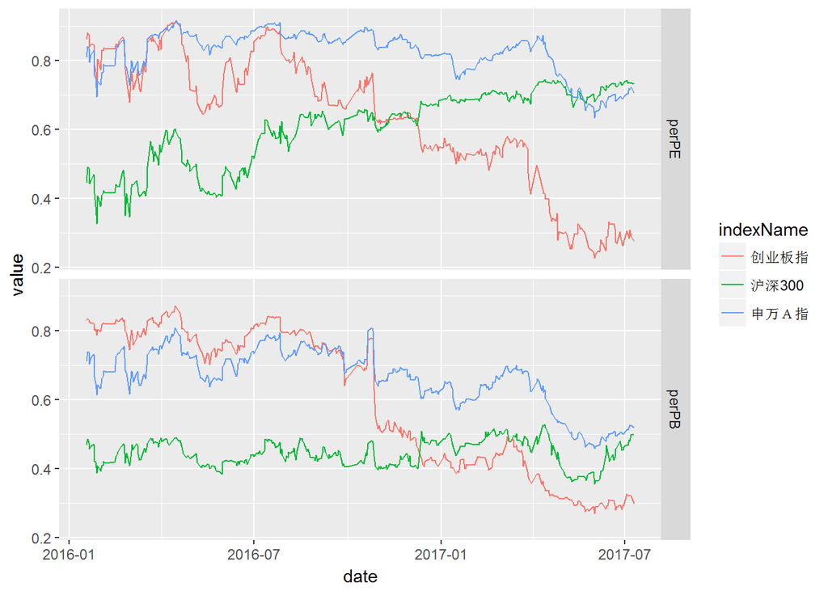

### (a3)指数估值概览

纳入观察的指数最新的估值情况如下表，根据市盈率和市净率分位数均值降序排列。

| 指数代码 | 指数简称 | 日期 | 动态市盈率 | 市盈率百分位 | 动态市净率 | 市净率百分位 |
| --- | --- | --- | --- | --- | --- | --- |
| EI000819 | 有色金属 | 2017-07-10 | 63.8 | 87% | 3.4 | 58% |
| EI000300 | 沪深300 | 2017-07-10 | 27.2 | 73% | 2.6 | 50% |
| EI000979 | 大宗商品 | 2017-07-10 | 35.6 | 67% | 2.7 | 56% |
| EI801003 | 申万Ａ指 | 2017-07-10 | 46.7 | 70% | 3.7 | 52% |
| EI399330 | 深证100 | 2017-07-10 | 34.0 | 72% | 3.6 | 49% |
| EI399959 | 军工指数 | 2017-07-10 | 83.5 | 59% | 4.0 | 51% |
| EI399005 | 中小板指P | 2017-07-10 | 38.3 | 53% | 4.6 | 42% |
| EI000905 | 中证500 | 2017-07-10 | 37.1 | 52% | 2.9 | 34% |
| EI000934 | 中证金融 | 2017-07-10 | 19.4 | 66% | 1.8 | 16% |
| EI000998 | 中证TMT | 2017-07-10 | 42.0 | 41% | 3.7 | 31% |
| EI000016 | 上证50 | 2017-07-10 | 16.8 | 52% | 1.6 | 15% |
| EI000827 | 中证环保 | 2017-07-10 | 36.4 | 36% | 3.1 | 30% |
| EI000922 | 中证红利 | 2017-07-10 | 16.2 | 37% | 1.7 | 27% |
| EI000932 | 中证消费 | 2017-07-10 | 31.4 | 47% | 3.6 | 13% |
| EI399006 | 创业板指 | 2017-07-10 | 46.4 | 28% | 4.4 | 30% |
| EI000933 | 中证医药 | 2017-07-10 | 33.3 | 24% | 3.8 | 5% |

### (a4)另类估值

我国10年期国债收益率、金银比价、金油比价，2000年以来的历史百分位如下图所示：

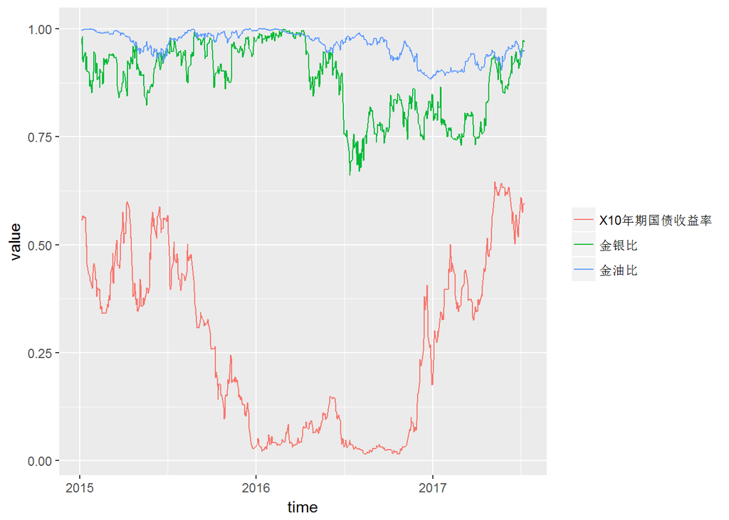

## B、基差及市场情绪

### (b1)基差走势

三大股指期货合约基差走势如下图，其中当月合约和次月合约年化基差百分比波动较大，仅展示合约基差百分比，当季合约和次季合约展示基差年化百分比：

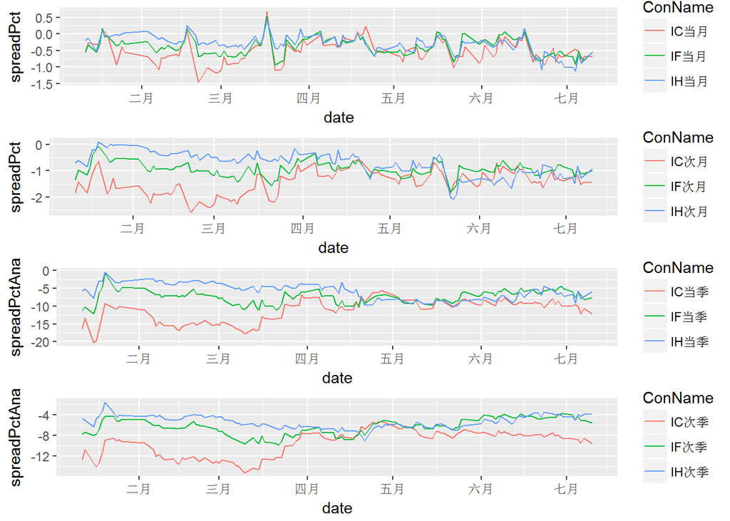

### (b2)基差概况

三大股指期货连续合约基差概况如下表，近月合约临近到期日，年化基差百分比数据波动较大：

| 日期 | 合约代码 | 合约收盘价 | 指数收盘价 | 基差 | 基差百分比 | 年化基差百分比 |
| --- | --- | --- | --- | --- | --- | --- |
| 2017-07-10 | IC1707 | 6165.0 | 6206.6 | -41.6 | -0.7% | -24.8% |
| 2017-07-10 | IC1708 | 6116.2 | 6206.6 | -90.4 | -1.5% | -14.5% |
| 2017-07-10 | IC1709 | 6073.8 | 6206.6 | -132.8 | -2.1% | -12.2% |
| 2017-07-10 | IC1712 | 5955.2 | 6206.6 | -251.4 | -4.0% | -9.6% |
| 2017-07-10 | IF1707 | 3634.0 | 3653.7 | -19.7 | -0.5% | -19.5% |
| 2017-07-10 | IF1708 | 3617.8 | 3653.7 | -35.9 | -1.0% | -9.6% |
| 2017-07-10 | IF1709 | 3604.0 | 3653.7 | -49.7 | -1.4% | -7.6% |
| 2017-07-10 | IF1712 | 3567.2 | 3653.7 | -86.5 | -2.4% | -5.6% |
| 2017-07-10 | IH1707 | 2536.2 | 2550.1 | -13.9 | -0.5% | -19.8% |
| 2017-07-10 | IH1708 | 2526.2 | 2550.1 | -23.9 | -0.9% | -9.1% |
| 2017-07-10 | IH1709 | 2523.0 | 2550.1 | -27.1 | -1.1% | -5.9% |
| 2017-07-10 | IH1712 | 2507.2 | 2550.1 | -42.9 | -1.7% | -3.9% |

### (b3)市场情绪(provided by han.qian)

市场情绪记录近60天每天自然涨跌停(剔除一字板)、创60日新高新低、多头排列空头排列(均线组合5,30,60,120)的股票数。

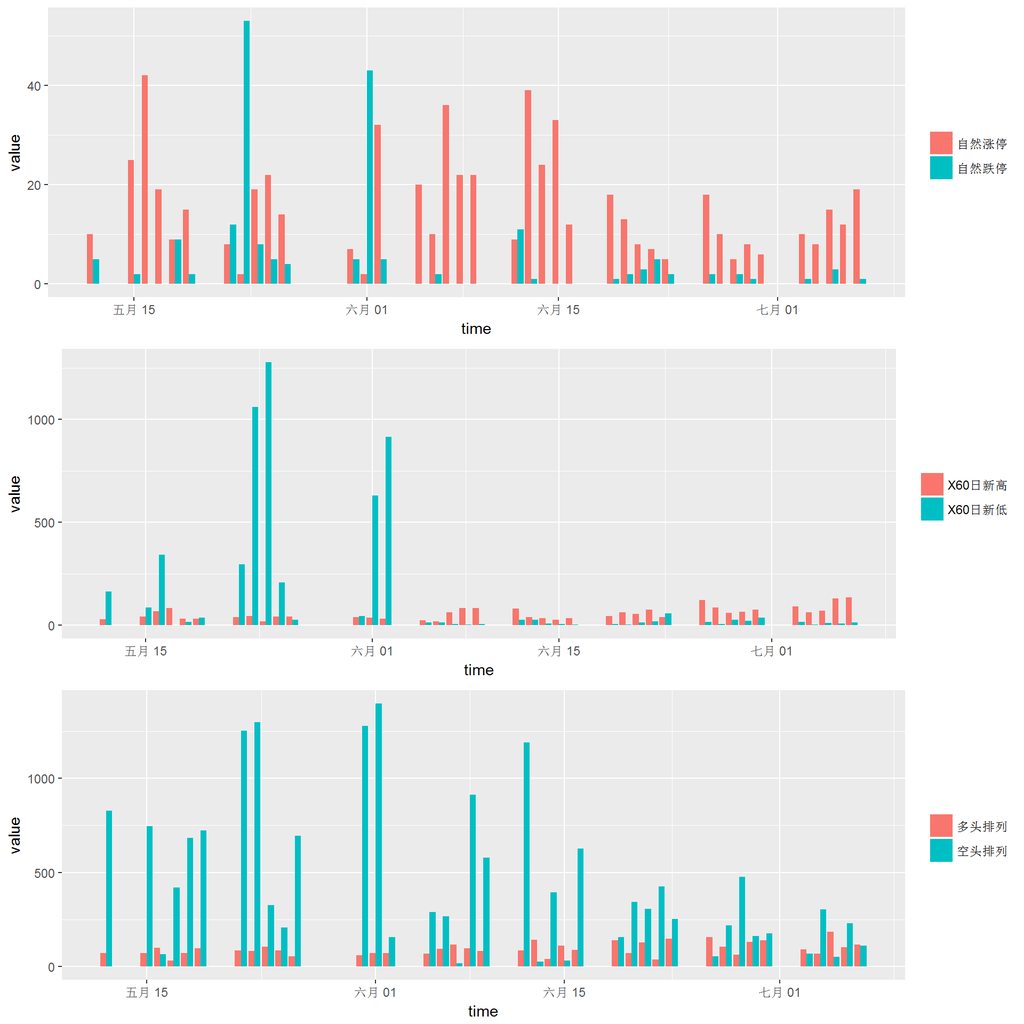

## C、套利和事件

### (c1)复牌股票套利

近两天复牌股票套利情况如下表：

[1] “No Arbitrage!”

### (c2)定增基金(provided by han.qian)

定增基金数据如下表，明细数据参见钱瀚的模板。

| 代码 | 名称 | 到期日期 | 最新净值 | 昨日收盘价 | 折溢价率 | 整体隐含折价率 | 大盘下跌0.1净值变化 |
| --- | --- | --- | --- | --- | --- | --- | --- |
| 168101.OF | 九泰锐智 | 20200814 | 1.16 | 0.94 | -18.5% | 4.3% | -10.2% |
| 168102.OF | 九泰锐富 | 20210204 | 1.00 | 0.78 | -21.6% | 2.6% | -5.7% |
| 501015.OF | 财通升级 | 20170908 | 0.98 | 0.92 | -6.2% | 0.6% | -9.2% |
| 160518.OF | 博时睿远 | 20171016 | 0.96 | 0.89 | -7.5% | 0.7% | -6.8% |

定增基金近期的净值走势如下图：

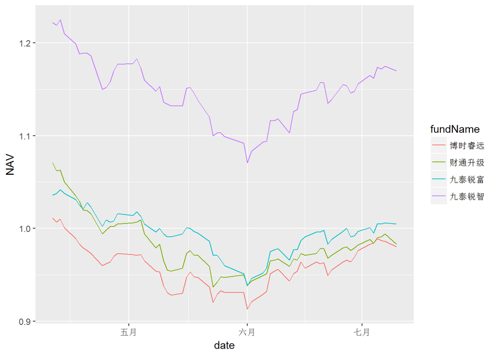

定增基金近期的折溢价率百分比走势如下图：

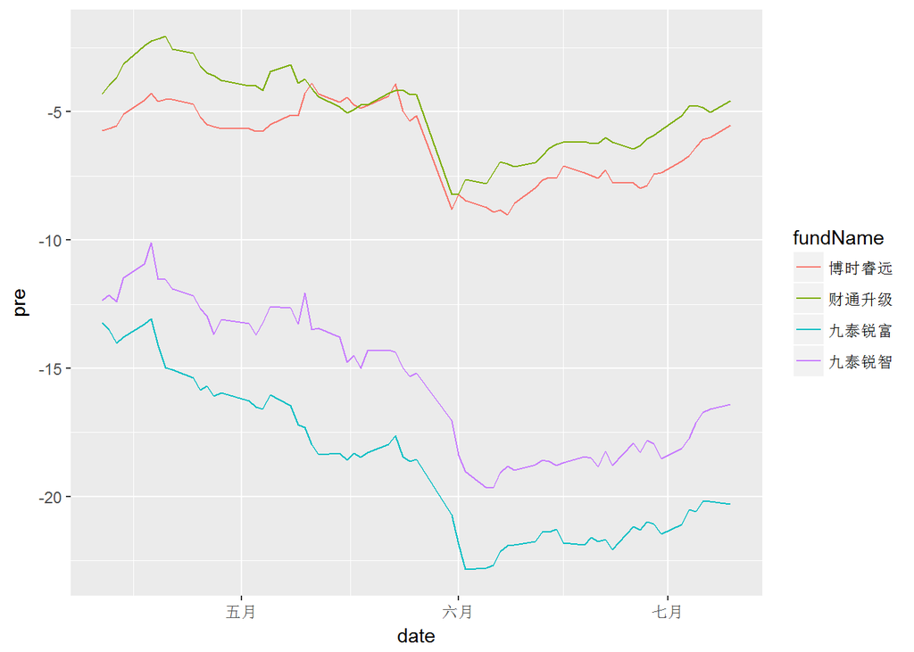

### (c3)解禁

解禁分成两个部分，定增解禁和IPO解禁，涨跌幅记录是过去十个交易日的股票涨跌幅和对应行业指数涨跌幅。伴随着去年下半年IPO逐步正常化，今后IPO解禁给市场造成的抛压会持续存在，所以纳入观察。近期定增解禁的股票情况如下表。

| 股票代码 | 股票简称 | 解禁日 | 解禁数量 | 解禁百分比 | 区间涨跌幅 | 所属行业指数 | 行业指数涨跌幅 |
| --- | --- | --- | --- | --- | --- | --- | --- |
| EQ000757 | 浩物股份 | 2017-07-12 | 0.85 | 23% | -2.6% | 申万汽车 | 0.2% |
| EQ300269 | 联建光电 | 2017-07-12 | 0.61 | 21% | -3.1% | 申万传媒 | -2.4% |
| EQ300274 | 阳光电源 | 2017-07-13 | 2.16 | 26% | 0.4% | 申万电气设备 | 1.3% |
| EQ000605 | 渤海股份 | 2017-07-14 | 0.72 | 58% | 0.2% | 申万公用事业 | -0.6% |
| EQ002147 | 新光圆成 | 2017-07-17 | 1.78 | 79% | -1.2% | 申万机械设备 | 1.3% |
| EQ600179 | 安通控股 | 2017-07-17 | 0.91 | 23% | -1.2% | 申万交通运输 | 0.7% |
| EQ002620 | 瑞和股份 | 2017-07-19 | 0.62 | 26% | -8.5% | 申万建筑装饰 | 0.8% |
| EQ300317 | 珈伟股份 | 2017-07-20 | 0.57 | 22% | 8.2% | 申万电气设备 | 1.3% |
| EQ603939 | 益丰药房 | 2017-07-21 | 0.43 | 27% | 3.4% | 申万医药生物 | -1.4% |
| EQ002718 | 友邦吊顶 | 2017-07-24 | 0.05 | 24% | 0.7% | 申万建筑材料 | 2.6% |
| EQ600483 | 福能股份 | 2017-07-24 | 9.70 | 336% | -1.2% | 申万公用事业 | -0.6% |
| EQ002594 | 比亚迪 | 2017-07-25 | 2.52 | 28% | -2.8% | 申万汽车 | 0.2% |

近期IPO解禁的股票情况如下表。

| 股票代码 | 股票简称 | 解禁日 | 解禁数量 | 解禁百分比 | 区间涨跌幅 | 所属行业指数 | 行业指数涨跌幅 | 上市日 |
| --- | --- | --- | --- | --- | --- | --- | --- | --- |
| EQ603069 | 海汽集团 | 2017-07-12 | 0.95 | 120% | -3.8% | 申万交通运输 | 0.7% | 2016-07-12 |
| EQ002803 | 吉宏股份 | 2017-07-12 | 0.17 | 59% | -0.4% | 申万轻工制造 | 2.5% | 2016-07-12 |
| EQ603009 | 北特科技 | 2017-07-19 | 0.72 | 132% | 8.0% | 申万汽车 | 0.2% | 2014-07-18 |
| EQ300517 | 海波重科 | 2017-07-19 | 0.16 | 62% | -4.0% | 申万建筑装饰 | 0.8% | 2016-07-19 |

### (c4)中小板业绩预增预测(provided by han.qian)

中小板规定正式财务报告发布的同时需要发布新一期的业绩预报，比如年报中会包含一季报预告的情况。我们假设公司的盈利状况有动量效应，年报预增的公司一季度也会预增，在正式财务报告发布前20个交易日开始埋伏，然后等正式报告发布日卖出。具体研究参见钱瀚前期的研究。需要注意的是这里的收益率仅做展示，仅仅是每日全部入选股票的平均收益率，并没有做成一个事件组合。

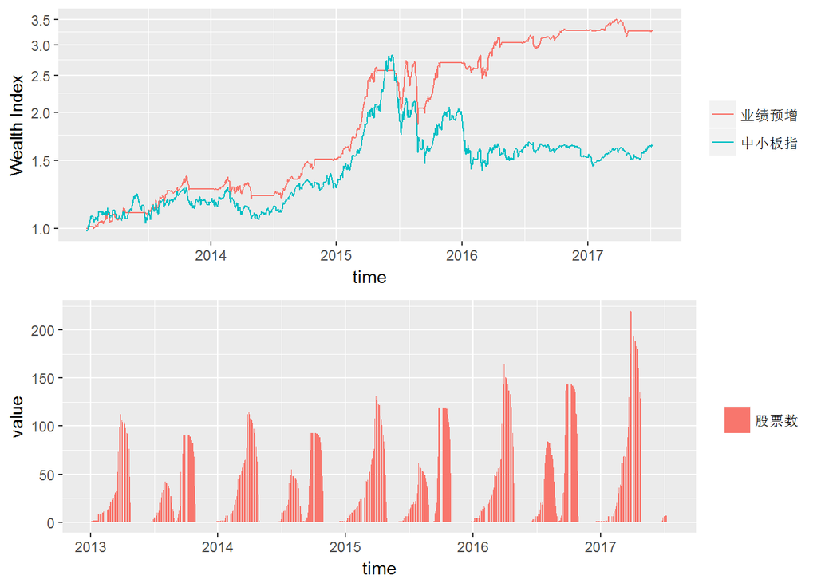

历年收益统计如下表所示。

|  | 业绩预增 | 中小板指 |
| --- | --- | --- |
| 2013-01-04 ~ 2013-12-31 | 26.4% | 17.5% |
| 2014-01-02 ~ 2014-12-31 | 20.0% | 9.7% |
| 2015-01-05 ~ 2015-12-31 | 77.7% | 53.7% |
| 2016-01-04 ~ 2016-12-30 | 21.9% | -22.9% |
| 2017-01-03 ~ 2017-07-10 | -0.5% | 7.1% |
| Cumulative Return | 227.0% | 63.6% |
| Annualized Return | 30.0% | 11.5% |